# Comments on Gini Map of Vietnam

Hiroshi Suzuki

# Setup

I tried to use a smallest set of packages to understand the functionality of each package clearly.

```r
library(tidyverse)
library(readxl)
library(maps)
library(sf)
```

## Import GINI of the World Data

The following is my personal memo:

> Gini index Gini index measures the extent to which the distribution of income (or, in some cases, consumption expenditure) among individuals or households within an economy deviates from a perfectly equal distribution. A Lorenz curve plots the cumulative percentages of total income received against the cumulative number of recipients, starting with the poorest individual or household. The Gini index measures the area between the Lorenz curve and a hypothetical line of absolute equality, expressed as a percentage of the maximum area under the line. Thus a Gini index of 0 represents perfect equality, while an index of 100 implies perfect inequality. https://data.worldbank.org/indicator/SI.POV.GINI

```r
gini_world <- read_excel('Giniworld.xlsx')
gini_world
```

| country | Gini |
| --- | --- |
| Aruba | NA |
| Africa Eastern and Southern | NA |
| Afghanistan | NA |
| Africa Western and Central | NA |
| Angola | 0.513 |
| Albania | 0.294 |
| Andorra | NA |
| Arab World | NA |
| United Arab Emirates | 0.260 |
| Argentina | 0.420 |

[output cut: 259 more lines]

## World Map

See class note.

```r
world_map <- map_data("world")
world_map_rev <- world_map %>%
  mutate(region = case_when(region == "Macedonia" ~ "North Macedonia",
                            region == "Ivory Coast"  ~ "Cote d'Ivoire",
                            region == "Democratic Republic of the Congo"  ~ "Congo, Dem. Rep.",
                            region == "Republic of Congo" ~  "Congo, Rep.",
                            region == "UK" ~  "United Kingdom",
#                            region == "USA" ~  "United States",
                            region == "Laos" ~  "Lao PDR",
                            region == "Slovakia" ~  "Slovak Republic",
                            region == "Saint Lucia" ~  "St. Lucia",
                            region == "Kyrgyzstan"  ~  "Kyrgyz Republic",
                            region == "Micronesia" ~ "Micronesia, Fed. Sts.",
                            region == "Swaziland"  ~ "Eswatini",
                            region == "Virgin Islands"  ~ "Virgin Islands (U.S.)",
#                            region == "Russia" ~ "Russian Federation",
                            region == "Egypt" ~ "Egypt, Arab Rep.",
                            region == "South Korea" ~ "Korea, Rep.",
                            region == "North Korea" ~ "Korea, Dem. People's Rep.",
                            region == "Iran" ~ "Iran, Islamic Rep.",
                            region == "Brunei" ~ "Brunei Darussalam",
                            region == "Venezuela" ~ "Venezuela, RB",
                            region == "Yemen" ~ "Yemen, Rep.",
                            region == "Bahamas" ~ "Bahamas, The",
                            region == "Syria" ~ "Syrian Arab Republic",
                            region == "Turkey" ~ "Turkiye",
                            region == "Cape Verde" ~ "Cabo Verde",
                            region == "Gambia" ~ "Gambia, The",
                            region == "Czech Republic" ~ "Czechia",
                            TRUE ~ region))
```

## Import Gini of Viet Nam Data

Used your data.

```r
gini_vietnam <- read_excel('DataVN.xls')
gini_vietnam
```

| id | province | sub region | gini | icgap | top20 | GDP 2021 (Billion VND) | GDPPC (Thoudsand VND) | Investment | emp | lit | edu | pop | poprate | ubrate | General average income |
| --- | --- | --- | --- | --- | --- | --- | --- | --- | --- | --- | --- | --- | --- | --- | --- |
| 1 | Ha Noi | Red River Delta | 0.33792 | 6.321822 | 42.06828 | 1067540.0 | 128143.29 | 411261.000 | 46.09 | 98.94 | 23.9 | 8330.83 | 1.02 | 49.159148 | 6002 |
| 2 | Vinh Phuc | Red River Delta | 0.28408 | 4.780697 | 39.48452 | 136183.0 | 114268.57 | 45796.747 | 47.83 | 98.66 | 9.1 | 1191.78 | 1.74 | 30.066791 | 4511 |
| 3 | Bac Ninh | Red River Delta | 0.28756 | 4.984416 | 38.98663 | 227614.6 | 155586.04 | 58219.000 | 51.02 | 98.35 | 9.7 | 1462.95 | 3.04 | 36.648553 | 4917 |
| 4 | Quang Ninh | Red River Delta | 0.26028 | 4.298525 | 36.46464 | 238186.3 | 176323.28 | 88728.125 | 48.44 | 97.15 | 11.3 | 1350.85 | 0.99 | 67.859496 | 3992 |
| 5 | Hai Duong | Red River Delta | 0.29480 | 5.214749 | 41.02766 | 149090.0 | 76978.28 | 49319.000 | 48.02 | 98.73 | 8.0 | 1936.78 | 1.04 | 31.659765 | 4304 |
| 6 | Hai Phong | Red River Delta | 0.26448 | 4.243267 | 37.71978 | 315709.6 | 152340.82 | 161217.528 | 48.81 | 99.19 | 13.0 | 2072.39 | 0.92 | 45.512669 | 5093 |
| 7 | Hung Yen | Red River Delta | 0.26404 | 4.680025 | 36.17691 | 112305.7 | 87428.05 | 36407.460 | 52.04 | 98.19 | 7.5 | 1284.55 | 1.21 | 16.625926 | 4192 |
| 8 | Thai Binh | Red River Delta | 0.20688 | 3.246885 | 32.45387 | 98310.0 | 52413.55 | 54876.589 | 50.25 | 98.90 | 5.5 | 1875.66 | 0.29 | 11.813442 | 4334 |
| 9 | Ha Nam | Red River Delta | 0.29656 | 5.545687 | 39.63014 | 66895.2 | 76432.44 | 35718.831 | 49.40 | 98.86 | 7.7 | 875.22 | 1.54 | 27.982679 | 4372 |
| 10 | Nam Dinh | Red River Delta | 0.18996 | 2.932533 | 32.07479 | 84096.8 | 45797.62 | 42983.500 | 50.86 | 98.41 | 6.6 | 1836.27 | 3.09 | 20.235042 | 4413 |

[output cut: 53 more lines]

```r
colnames(gini_vietnam)
```

```
 [1] "id"                     "province"
 [3] "sub region"             "gini"
 [5] "icgap"                  "top20"
 [7] "GDP 2021 (Billion VND)" "GDPPC (Thoudsand VND)"
 [9] "Investment"             "emp"
[11] "lit"                    "edu"
[13] "pop"                    "poprate"
[15] "ubrate"                 "General average income"
```

# Gini Map of the World

```r
gini_world %>% arrange(country)
```

| country | Gini |
| --- | --- |
| Afghanistan | NA |
| Africa Eastern and Southern | NA |
| Africa Western and Central | NA |
| Albania | 0.294 |
| Algeria | 0.276 |
| American Samoa | NA |
| Andorra | NA |
| Angola | 0.513 |
| Antigua and Barbuda | NA |
| Arab World | NA |

[output cut: 259 more lines]

```r
world_map_rev %>% distinct(region) %>%
  anti_join(gini_world, by = c("region" = "country")) %>% as_tibble()
```

| region |
| --- |
| Anguilla |
| Antarctica |
| French Southern and Antarctic Lands |
| Antigua |
| Barbuda |
| Saint Barthelemy |
| Cook Islands |
| Canary Islands |
| Falkland Islands |
| Reunion |

[output cut: 40 more lines]

- There are many missing countries in world map. If you use it please check carefully.

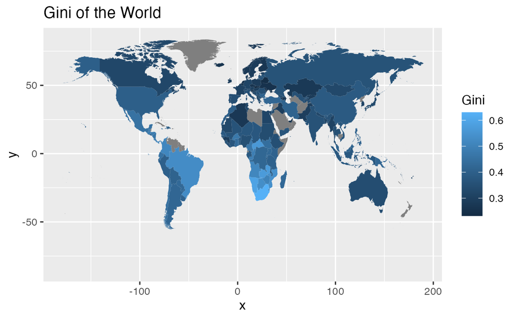

# Gini Map of Vietnam, Part I

I used a different map data (in spatial format) of Vietnam in the following.

Source: https://rpubs.com/Linh-LTP/890658

```r
link <- "https://data.opendevelopmentmekong.net/dataset/999c96d8-fae0-4b82-9a2b-e481f6f50e12/resource/2818c2c5-e9c3-440b-a9b8-3029d7298065/download/diaphantinhenglish.geojson?fbclid=IwAR1coUVLkuEoJRsgaH81q6ocz1nVeGBirqpKRBN8WWxXQIJREUL1buFi1eE"

vn_spatial <- st_read(link)
```

## Test

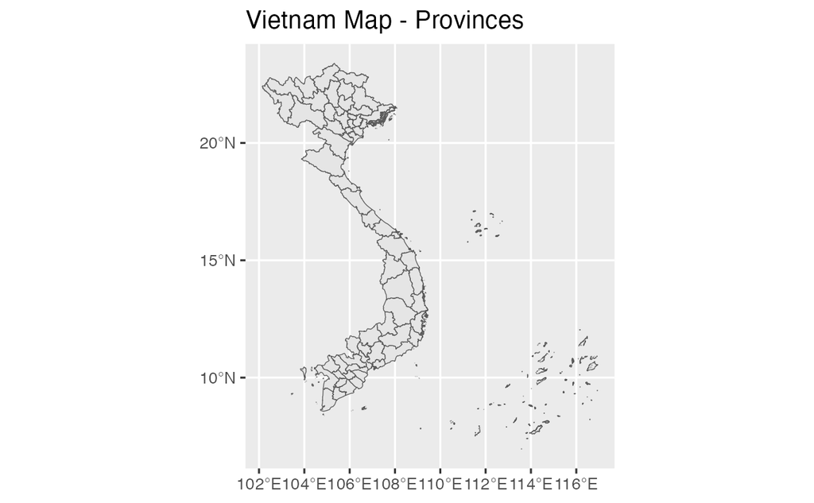

```r
ggplot() +
  geom_sf(data = vn_spatial) +
  labs(title = "Vietnam Map - Provinces")
```

## Compare with Gini Data of Vietnam

```r
vn_spatial %>% as_tibble() %>% arrange(Name)
```

| Code | Name | geometry |
| --- | --- | --- |
| AD01 | An Giang |  |
| AD01 | Ba Ria - Vung Tau |  |
| AD01 | Bac Giang |  |
| AD01 | Bac Kan |  |
| AD01 | Bac Lieu |  |
| AD01 | Bac Ninh |  |
| AD01 | Ben Tre |  |
| AD01 | Binh Dinh |  |
| AD01 | Binh Duong |  |
| AD01 | Binh Phuoc |  |

[output cut: 53 more lines]

```r
gini_vietnam %>% arrange(province)
```

| id | province | sub region | gini | icgap | top20 | GDP 2021 (Billion VND) | GDPPC (Thoudsand VND) | Investment | emp | lit | edu | pop | poprate | ubrate | General average income |
| --- | --- | --- | --- | --- | --- | --- | --- | --- | --- | --- | --- | --- | --- | --- | --- |
| 57 | An Giang | Mekong River Delta | 0.33112 | 6.411043 | 42.89568 | 92237.9 | 48304.49 | 13186.195 | 46.28 | 91.28 | 7.0 | 1909.51 | 0.26 | 33.831893 | 3406 |
| 49 | Ba Ria Vung Tau | South East | 0.35304 | 7.020322 | 45.29547 | 330754.4 | 281234.61 | 51966.926 | 48.04 | 97.73 | 10.2 | 1176.08 | 0.69 | 58.403340 | 4419 |
| 20 | Bac Giang | Northern midlands and mountain areas | 0.28528 | 4.836797 | 39.85996 | 129836.7 | 69237.38 | 62895.000 | 50.41 | 98.20 | 5.8 | 1875.24 | 1.81 | 18.219535 | 3966 |
| 14 | Bac Kan | Northern midlands and mountain areas | 0.42468 | 11.378723 | 50.28679 | 13531.4 | 41800.99 | 3720.440 | 43.27 | 93.49 | 8.1 | 323.71 | 2.26 | 22.585030 | 2125 |
| 62 | Bac Lieu | Mekong River Delta | 0.21500 | 3.367358 | 33.85097 | 53016.4 | 57720.00 | 31860.778 | 51.25 | 94.48 | 4.6 | 918.51 | 0.55 | 27.755822 | 3642 |
| 3 | Bac Ninh | Red River Delta | 0.28756 | 4.984416 | 38.98663 | 227614.6 | 155586.04 | 58219.000 | 51.02 | 98.35 | 9.7 | 1462.95 | 3.04 | 36.648553 | 4917 |
| 53 | Ben Tre | Mekong River Delta | 0.34644 | 6.582817 | 44.09636 | 55964.2 | 43192.25 | 20099.000 | 58.74 | 94.46 | 4.2 | 1295.70 | 0.26 | 9.899668 | 3367 |
| 35 | Binh Dinh | North Central and Central coastal areas | 0.35220 | 7.840459 | 43.28478 | 95311.4 | 63190.44 | 42366.000 | 53.97 | 96.35 | 8.3 | 1508.32 | 1.36 | 41.159038 | 3469 |
| 47 | Binh Duong | South East | 0.23180 | 3.457135 | 34.74600 | 408860.0 | 157448.23 | 123370.255 | 62.40 | 97.30 | 6.6 | 2596.79 | 0.63 | 84.322567 | 7123 |
| 45 | Binh Phuoc | South East | 0.29640 | 5.214929 | 40.43912 | 77838.4 | 75992.54 | 25707.590 | 56.95 | 93.44 | 5.4 | 1024.29 | 1.30 | 24.166984 | 4002 |

[output cut: 53 more lines]

```r
vn_spatial %>% anti_join(gini_vietnam, by = c("Name" = "province")) %>% as_tibble()
```

| Code | Name | geometry |
| --- | --- | --- |
| AD01 | Ba Ria - Vung Tau |  |
| AD01 | Thua Thien - Hue |  |
| AD01 | TP. Ho Chi Minh |  |

```r
vn_spatial <- vn_spatial %>% mutate(Name = case_when(
  Name == "Ba Ria - Vung Tau" ~ "Ba Ria Vung Tau",
  Name == "Thua Thien - Hue" ~ "Thua Thien Hue",
  Name == "TP. Ho Chi Minh" ~ "Ho Chi Minh City",
  TRUE ~ Name))
```

## Join Two Datasets

```r
vietnam_gini_map <- vn_spatial %>% left_join(gini_vietnam, by = c("Name" = "province"))
vietnam_gini_map
```

```
Simple feature collection with 63 features and 17 fields
Geometry type: MULTIPOLYGON
Dimension:     XY
Bounding box:  xmin: 102.1421 ymin: 6.953306 xmax: 116.9473 ymax: 23.3939
Geodetic CRS:  WGS 84
First 10 features:
   Code            Name id                              sub region    gini
1  AD01        An Giang 57                      Mekong River Delta 0.33112
2  AD01 Ba Ria Vung Tau 49                              South East 0.35304
3  AD01       Bac Giang 20    Northern midlands and mountain areas 0.28528
4  AD01         Bac Kan 14    Northern midlands and mountain areas 0.42468
5  AD01        Bac Lieu 62                      Mekong River Delta 0.21500
6  AD01        Bac Ninh  3                         Red River Delta 0.28756
7  AD01         Ben Tre 53                      Mekong River Delta 0.34644
8  AD01       Binh Dinh 35 North Central and Central coastal areas 0.35220
```

[output cut: 35 more lines]

## Gini Map of Vietnam by Province

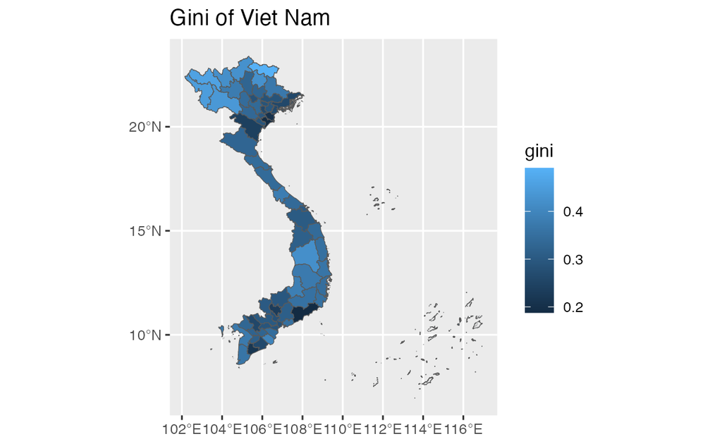

## Review

# Gini Map of Vietnam, Part II

## Get map data of Vietnam from GADM

```r
library(geodata)
map_vietnam0 <- gadm(country="VNM", level=1, path=tempdir())
class(map_vietnam0)
```

```
[1] "SpatVector"
attr(,"package")
[1] "terra"
```

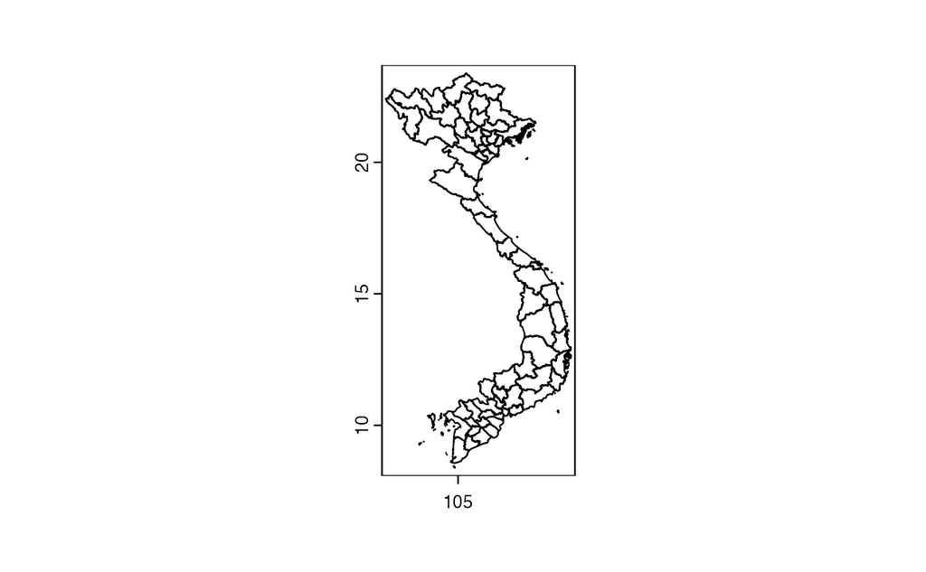

```r
plot(map_vietnam0)
```

```r
map_vietnam0
```

```
 class       : SpatVector
 geometry    : polygons
 dimensions  : 63, 11  (geometries, attributes)
 extent      : 102.1446, 109.4692, 8.381355, 23.39269  (xmin, xmax, ymin, ymax)
 coord. ref. : lon/lat WGS 84 (EPSG:4326)
```

| names : | GID_1 | GID_0 | COUNTRY | NAME_1 | VARNAME_1 | NL_NAME_1 | TYPE_1 | ENGTYPE_1 | CC_1 | HASC_1 | ISO_1 |
| --- | --- | --- | --- | --- | --- | --- | --- | --- | --- | --- | --- |
| type : |  |  |  |  |  |  |  |  |  |  |  |
| values : | VNM.1_1 | VNM | Vietnam | An Giang | An Giang | NA | Tỉnh | Province | NA | VN.AG | VN-44 |
|  | VNM.7_1 | VNM | Vietnam | Bà Rịa - Vũng Tàu | Ba Ria - Vung Tau | NA | Tỉnh | Province | NA | VN.BV | NA |
|  | VNM.3_1 | VNM | Vietnam | Bắc Giang | Bac Giang | NA | Tỉnh | Province | NA | VN.BG | NA |

```r
map_vietnam00 <- st_as_sf(map_vietnam0, row.names=NULL, optional=FALSE, geom=NULL)
map_vietnam00
```

```
Simple feature collection with 63 features and 11 fields
Geometry type: GEOMETRY
Dimension:     XY
Bounding box:  xmin: 102.1446 ymin: 8.381355 xmax: 109.4692 ymax: 23.39269
Geodetic CRS:  WGS 84
First 10 features:
      GID_1 GID_0 COUNTRY            NAME_1         VARNAME_1 NL_NAME_1
1   VNM.1_1   VNM Vietnam          An Giang          An Giang      <NA>
2   VNM.7_1   VNM Vietnam Bà Rịa - Vũng Tàu Ba Ria - Vung Tau      <NA>
3   VNM.3_1   VNM Vietnam         Bắc Giang         Bac Giang      <NA>
4   VNM.4_1   VNM Vietnam           Bắc Kạn           Bac Kan      <NA>
5   VNM.2_1   VNM Vietnam          Bạc Liêu          Bac Lieu      <NA>
6   VNM.5_1   VNM Vietnam          Bắc Ninh          Bac Ninh      <NA>
7   VNM.6_1   VNM Vietnam           Bến Tre           Ben Tre      <NA>
8   VNM.8_1   VNM Vietnam         Bình Định         Binh Dinh      <NA>
9   VNM.9_1   VNM Vietnam        Bình Dương        Binh Duong      <NA>
10 VNM.10_1   VNM Vietnam        Bình Phước        Binh Phuoc      <NA>
   TYPE_1 ENGTYPE_1 CC_1 HASC_1 ISO_1                       geometry
1    Tỉnh  Province <NA>  VN.AG VN-44 POLYGON ((105.5486 10.42948...
2    Tỉnh  Province <NA>  VN.BV  <NA> MULTIPOLYGON (((107.0901 10...
3    Tỉnh  Province <NA>  VN.BG  <NA> POLYGON ((106.2838 21.13225...
4    Tỉnh  Province <NA>  VN.BK  <NA> POLYGON ((105.8724 21.85575...
5    Tỉnh  Province <NA>  VN.BL  <NA> POLYGON ((105.4244 9.021305...
6    Tỉnh  Province <NA>  VN.BN  <NA> POLYGON ((106.1306 20.99494...
7    Tỉnh  Province <NA>  VN.BR  <NA> POLYGON ((106.719 10.03367,...
8    Tỉnh  Province <NA>  VN.BD  <NA> MULTIPOLYGON (((109.3704 13...
9    Tỉnh  Province <NA>  VN.BI  <NA> POLYGON ((106.7613 10.87455...
10   Tỉnh  Province <NA>  VN.BP  <NA> POLYGON ((106.8665 11.31349...
```

```r
vietnam_gini_map00 <- map_vietnam00 %>% left_join(gini_vietnam, by = c("VARNAME_1" = "province"))
vietnam_gini_map00
```

```
Simple feature collection with 63 features and 26 fields
Geometry type: GEOMETRY
Dimension:     XY
Bounding box:  xmin: 102.1446 ymin: 8.381355 xmax: 109.4692 ymax: 23.39269
Geodetic CRS:  WGS 84
First 10 features:
      GID_1 GID_0 COUNTRY            NAME_1         VARNAME_1 NL_NAME_1
1   VNM.1_1   VNM Vietnam          An Giang          An Giang      <NA>
2   VNM.7_1   VNM Vietnam Bà Rịa - Vũng Tàu Ba Ria - Vung Tau      <NA>
3   VNM.3_1   VNM Vietnam         Bắc Giang         Bac Giang      <NA>
4   VNM.4_1   VNM Vietnam           Bắc Kạn           Bac Kan      <NA>
5   VNM.2_1   VNM Vietnam          Bạc Liêu          Bac Lieu      <NA>
6   VNM.5_1   VNM Vietnam          Bắc Ninh          Bac Ninh      <NA>
7   VNM.6_1   VNM Vietnam           Bến Tre           Ben Tre      <NA>
8   VNM.8_1   VNM Vietnam         Bình Định         Binh Dinh      <NA>
```

[output cut: 57 more lines]

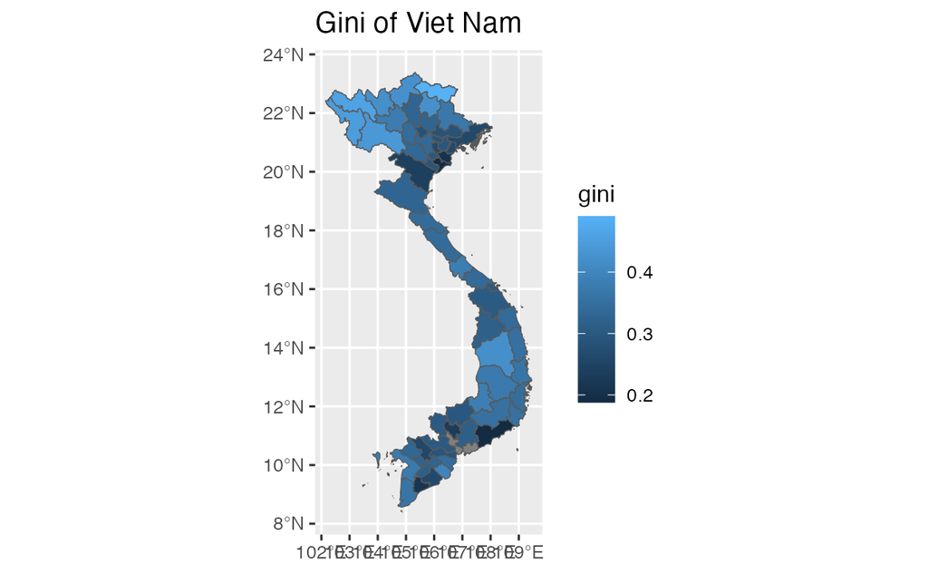

# Gini Map of Vietnam, Part III - Your Code

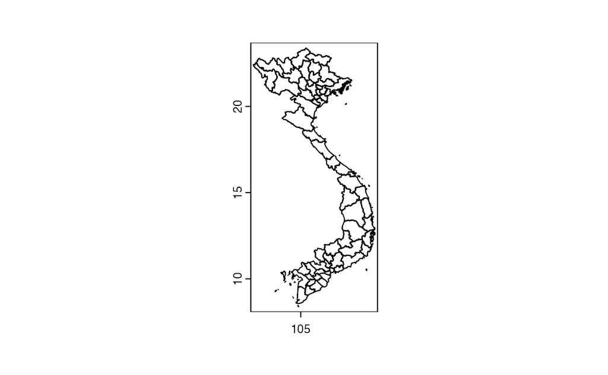

```r
mapvn0 <- gadm(country = "VNM", path = tempdir(), level = 1)
plot(mapvn0)
```

```r
mapvn <- st_as_sf(mapvn0) #the data was already saved as data frames after this command
```

```r
head(mapvn)
```

```
Simple feature collection with 6 features and 11 fields
Geometry type: GEOMETRY
Dimension:     XY
Bounding box:  xmin: 104.7784 ymin: 9.01717 xmax: 107.5714 ymax: 22.74153
Geodetic CRS:  WGS 84
    GID_1 GID_0 COUNTRY            NAME_1         VARNAME_1 NL_NAME_1
1 VNM.1_1   VNM Vietnam          An Giang          An Giang      <NA>
2 VNM.7_1   VNM Vietnam Bà Rịa - Vũng Tàu Ba Ria - Vung Tau      <NA>
3 VNM.3_1   VNM Vietnam         Bắc Giang         Bac Giang      <NA>
4 VNM.4_1   VNM Vietnam           Bắc Kạn           Bac Kan      <NA>
5 VNM.2_1   VNM Vietnam          Bạc Liêu          Bac Lieu      <NA>
6 VNM.5_1   VNM Vietnam          Bắc Ninh          Bac Ninh      <NA>
  TYPE_1 ENGTYPE_1 CC_1 HASC_1 ISO_1                       geometry
1   Tỉnh  Province <NA>  VN.AG VN-44 POLYGON ((105.5486 10.42948...
2   Tỉnh  Province <NA>  VN.BV  <NA> MULTIPOLYGON (((107.0901 10...
3   Tỉnh  Province <NA>  VN.BG  <NA> POLYGON ((106.2838 21.13225...
4   Tỉnh  Province <NA>  VN.BK  <NA> POLYGON ((105.8724 21.85575...
5   Tỉnh  Province <NA>  VN.BL  <NA> POLYGON ((105.4244 9.021305...
6   Tỉnh  Province <NA>  VN.BN  <NA> POLYGON ((106.1306 20.99494...
```

```r
write.csv(mapvn,"mapvn.csv",row.names=TRUE)
names(mapvn)
```

```
 [1] "GID_1"     "GID_0"     "COUNTRY"   "NAME_1"    "VARNAME_1" "NL_NAME_1"
 [7] "TYPE_1"    "ENGTYPE_1" "CC_1"      "HASC_1"    "ISO_1"     "geometry"
```

```r
mapvn_gini <- mapvn %>% left_join(gini_vietnam, by = c("VARNAME_1" = "province"))
mapvn_gini
```

```
Simple feature collection with 63 features and 26 fields
Geometry type: GEOMETRY
Dimension:     XY
Bounding box:  xmin: 102.1446 ymin: 8.381355 xmax: 109.4692 ymax: 23.39269
Geodetic CRS:  WGS 84
First 10 features:
      GID_1 GID_0 COUNTRY            NAME_1         VARNAME_1 NL_NAME_1
1   VNM.1_1   VNM Vietnam          An Giang          An Giang      <NA>
2   VNM.7_1   VNM Vietnam Bà Rịa - Vũng Tàu Ba Ria - Vung Tau      <NA>
3   VNM.3_1   VNM Vietnam         Bắc Giang         Bac Giang      <NA>
4   VNM.4_1   VNM Vietnam           Bắc Kạn           Bac Kan      <NA>
5   VNM.2_1   VNM Vietnam          Bạc Liêu          Bac Lieu      <NA>
6   VNM.5_1   VNM Vietnam          Bắc Ninh          Bac Ninh      <NA>
7   VNM.6_1   VNM Vietnam           Bến Tre           Ben Tre      <NA>
8   VNM.8_1   VNM Vietnam         Bình Định         Binh Dinh      <NA>
```

[output cut: 57 more lines]

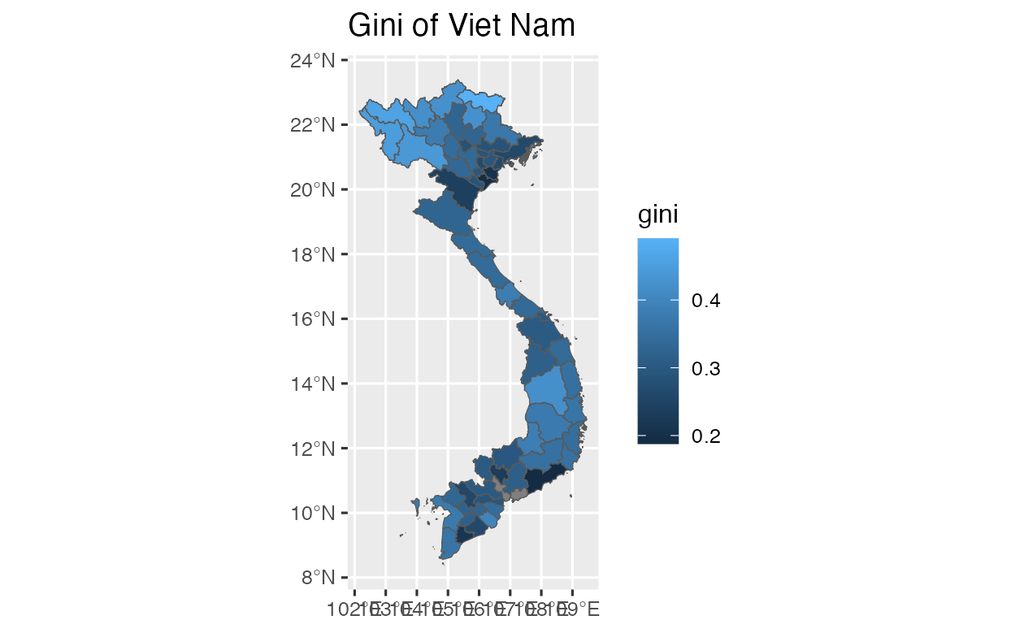

### Review

- You should check the province name with those in the map data as I did in my first try. I leave this process to you.

### Convert Geometry data into long/lat data???

I supposed that if I can convert geometry data into long/lat data, the map can be drawn.

# References: (same as yours)

1. https://stackoverflow.com/questions/47661354/converting-geometry-to-longitude-latitude-coordinates-in-r
2. https://community.rstudio.com/t/convert-geometry-column-with-lists-of-longitude-latitude-coordinates/67114/7
3. https://rstudio-pubs-static.s3.amazonaws.com/647153_88833beacf2c4107ad76bc3bc7bc8b9d.html
4. https://rdrr.io/cran/terra/man/as.data.frame.html This one: https://stackoverflow.com/questions/73825468/converting-spatvector-objects-to-data-frames-for-use-in-ggplot2